# IODS course project

Gonzalo de Quesada

# About the project

I enroll the course to learn the basics of open data sciences to implement it on my thesis

https://github.com/gonzalodqa/IODS-project

## “Chapter 2. Regression and model validation”

Data

Our original data

```r
learning2014col <- read.csv("C:/Users/D E L L/Documents/GitHub/IODS-project/Data/learning2014.csv")
str(learning2014col)
```

```
## 'data.frame':    166 obs. of  7 variables:
##  $ gender  : Factor w/ 2 levels "F","M": 1 2 1 2 2 1 2 1 2 1 ...
##  $ Age     : int  53 55 49 53 49 38 50 37 37 42 ...
##  $ Attitude: num  3.7 3.1 2.5 3.5 3.7 3.8 3.5 2.9 3.8 2.1 ...
##  $ deep    : num  3.58 2.92 3.5 3.5 3.67 ...
##  $ stra    : num  3.38 2.75 3.62 3.12 3.62 ...
##  $ surf    : num  2.58 3.17 2.25 2.25 2.83 ...
##  $ Points  : int  25 12 24 10 22 21 21 31 24 26 ...
```

```r
dim(learning2014col)
```

```
## [1] 166   7
```

the data have 7 variables: Gender: It has 2 levels: M for male, F for female

Age: age of the students.

Attitude: attitude towards statistics.

Deep: deep approach learning and it is a combination of variables including: seeking meaning, relating ideas and use of evidence. This variables measure sto what extent the student has the intention to maximize understanding, with a true commitment to learning.

Stra: strategic approach and it is a combination of variables including: organized studying and time management. This variables measures to what extent the students organize their studying

Surf: surface approach learning and it is a combination of variables including: lack of purpose, unrelated memorising and syllabus-boundness.This variable measures to what extent the student memorizes without understanding, with a serious lack of personal engagement in the learning process.

Points: the exam points that students obtained.

for a graphic overviwe we will use ggplot2 library because it creates scatter plots and correlation value. the mapping describes the aesthetic parameters and the colour between male and female.

```r
library(ggplot2)

library(GGally)
```

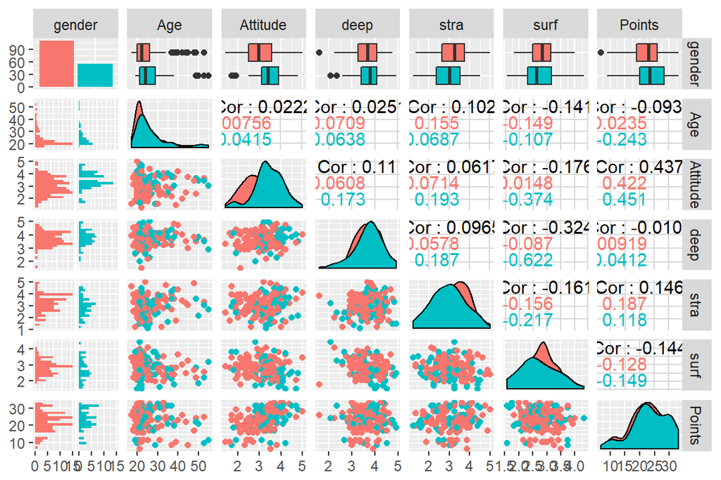

```r
p <- ggpairs(learning2014col, mapping = aes(col=gender), lower=list(combo=wrap("facethist", bins=20)))
p
```

using this model we choose three variables as explanatory variables (surf, stra, attitude) of the dependent variable (exam points)

```r
model <- lm(Points ~ Attitude + stra + surf, learning2014col)
model
```

```
##
## Call:
## lm(formula = Points ~ Attitude + stra + surf, data = learning2014col)
##
## Coefficients:
## (Intercept)     Attitude         stra         surf
##     11.0171       3.3952       0.8531      -0.5861
```

the model with only one variable (attitude)

```r
model1 <- lm(Points ~ Attitude, learning2014col)
model1
```

```
##
## Call:
## lm(formula = Points ~ Attitude, data = learning2014col)
##
## Coefficients:
## (Intercept)     Attitude
##      11.637        3.525
```

## residual vs fitted values

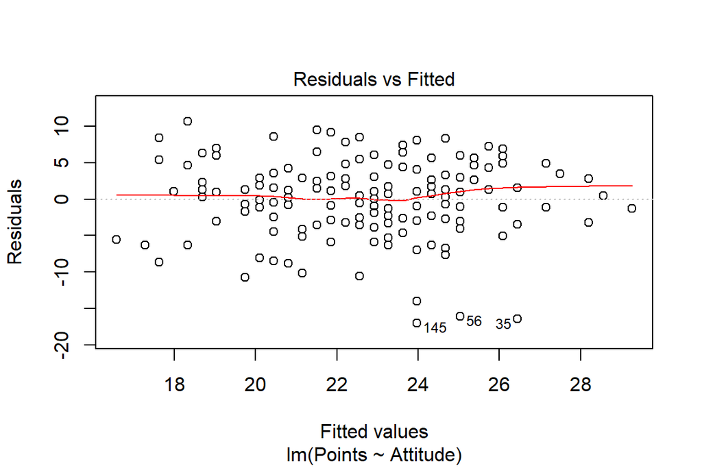

```r
plot(model1, 1)
```

## normal qq-plot

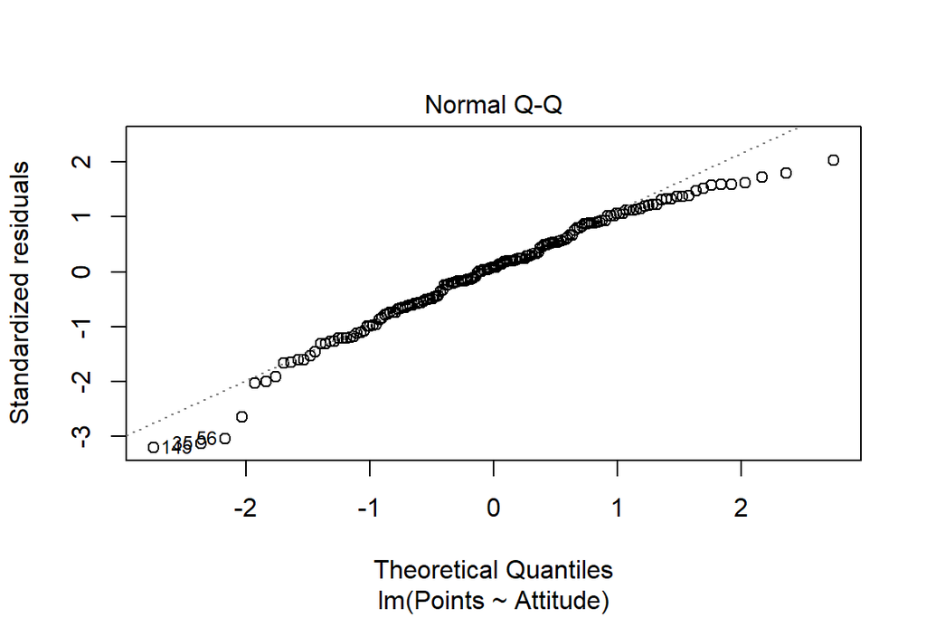

```r
plot(model1, 2)
```

## residual vs lererage

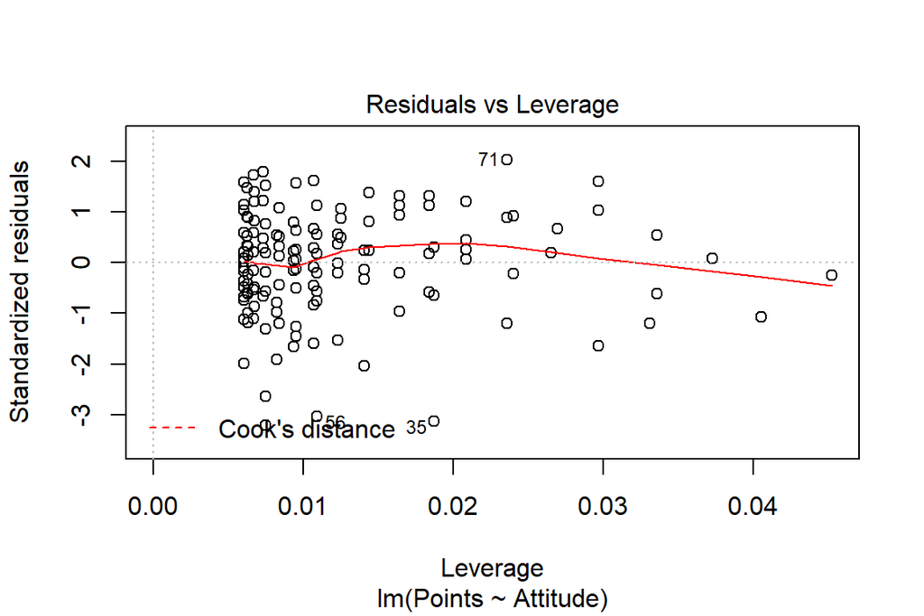

```r
plot(model1, 5)
```

## “Chapter 3. Logistic regfression”"

In this chapter we will analyse the relations between high/low alcohol consumption, and the other variables using logistic regressions.

## Data description

The data was obtained from the Machine Learning Repository. It contains 2 datasets, student performance in mathematics and in portuguese.

the data have 35 variables and 382 observations.amongs this we can find sex, grades, school, age, family size, job, address, etc.

We will analyse the high consumption of alcohol among students.

```r
alc <- read.table("C:/Users/D E L L/Documents/GitHub/IODS-project/Data/alc.csv", header = TRUE, sep = ",")

library(dplyr)
glimpse(alc)
```

```
## Observations: 382
## Variables: 35
## $ school     <fctr> GP, GP, GP, GP, GP, GP, GP, GP, GP, GP, GP, GP, GP...
## $ sex        <fctr> F, F, F, F, F, M, M, F, M, M, F, F, M, M, M, F, F,...
## $ age        <int> 18, 17, 15, 15, 16, 16, 16, 17, 15, 15, 15, 15, 15,...
## $ address    <fctr> U, U, U, U, U, U, U, U, U, U, U, U, U, U, U, U, U,...
## $ famsize    <fctr> GT3, GT3, LE3, GT3, GT3, LE3, LE3, GT3, LE3, GT3, ...
## $ Pstatus    <fctr> A, T, T, T, T, T, T, A, A, T, T, T, T, T, A, T, T,...
## $ Medu       <int> 4, 1, 1, 4, 3, 4, 2, 4, 3, 3, 4, 2, 4, 4, 2, 4, 4, ...
## $ Fedu       <int> 4, 1, 1, 2, 3, 3, 2, 4, 2, 4, 4, 1, 4, 3, 2, 4, 4, ...
## $ Mjob       <fctr> at_home, at_home, at_home, health, other, services...
## $ Fjob       <fctr> teacher, other, other, services, other, other, oth...
## $ reason     <fctr> course, course, other, home, home, reputation, hom...
## $ nursery    <fctr> yes, no, yes, yes, yes, yes, yes, yes, yes, yes, y...
## $ internet   <fctr> no, yes, yes, yes, no, yes, yes, no, yes, yes, yes...
```

[output cut: 22 more lines]

## Hypothesis (4 variables)

*Failures: Positive correlation, The more alcohol the more failures.

*Absences: Positive correlation, the more alcohol consumption the more absences.

*Final Grades: Negative correlation, higher alcohol consumption equals lower grades.

*Study time: Negative correlation, higher alcohol consumption, less study time.

## Explore the variables and their relationships with alcohol consumption

Bar plot

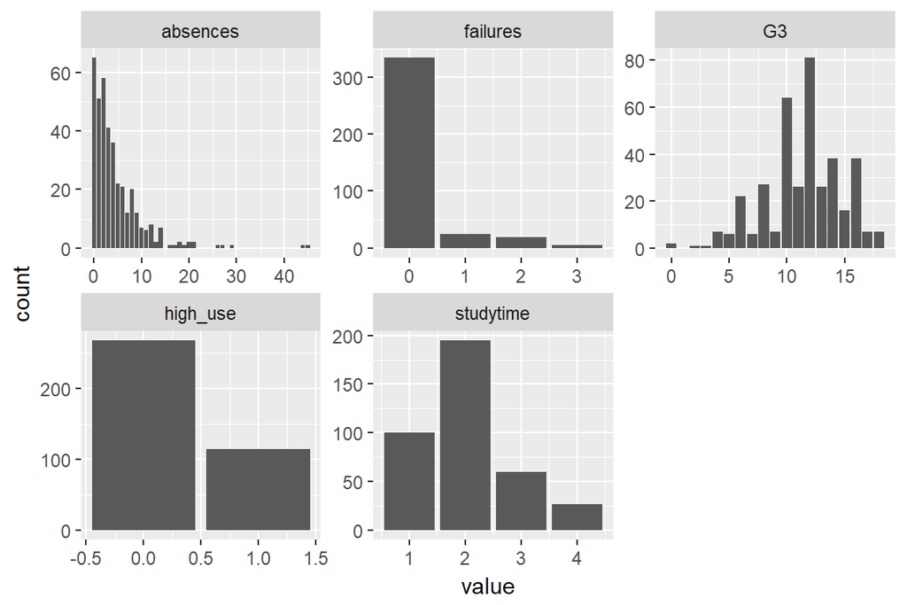

```r
chosen_variables <- subset(alc, select = c("high_use", "failures", "absences", "G3", "studytime"))
library(tidyr)
library(ggplot2)
gather(chosen_variables) %>% ggplot(aes(value)) + facet_wrap("key", scales = "free") + geom_bar()
```

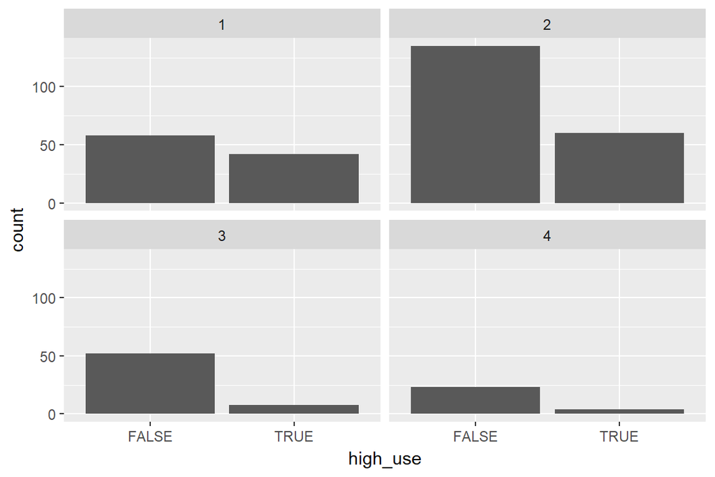

```r
g1 <- ggplot(alc, aes(x = high_use))
g1 + geom_bar() + facet_wrap("studytime")
```

Box plot

We will explore the variable grades by the gender of the students.

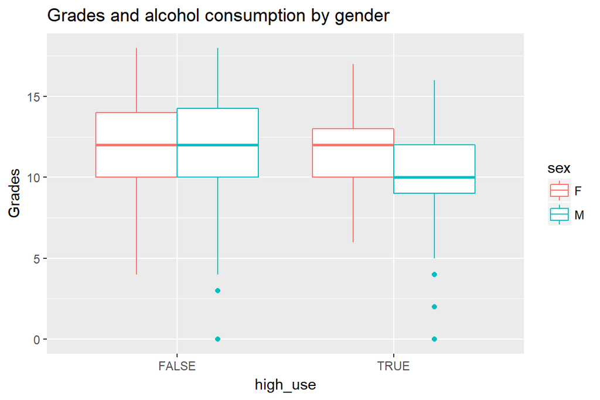

```r
g2 <- ggplot(alc, aes(x= high_use, y = G3, col = sex))
g2 + geom_boxplot() + ylab("Grades") + ggtitle("Grades and alcohol consumption by gender")
```

Cross-tabulation

Here we can explore the numerical values.

First we will start with the variable grades. As asume in the hypotesis we see that the students with higher alcohol consumption show less average grades than the other students.

```r
alc %>% group_by (high_use) %>% summarise (count = n(), mean_grade = mean (G3))
```

```
## # A tibble: 2 x 3
##   high_use count mean_grade
##      <lgl> <int>      <dbl>
## 1    FALSE   268   11.73507
## 2     TRUE   114   10.80702
```

```r
alc %>% group_by (high_use) %>% summarise (count = n(), mean_grade = mean (G3), mean_absences = mean(absences), mean_failures = mean(failures))
```

```
## # A tibble: 2 x 5
##   high_use count mean_grade mean_absences mean_failures
##      <lgl> <int>      <dbl>         <dbl>         <dbl>
## 1    FALSE   268   11.73507      3.705224     0.1417910
## 2     TRUE   114   10.80702      6.368421     0.3421053
```

If we add study time we can see that students with high alcohol consumption show less study time than their conterparts.

```r
alc %>% group_by (high_use) %>% summarise (count = n(), mean_grade = mean (G3), mean_absences = mean(absences), mean_failures = mean(failures), mean_studytime = mean(studytime))
```

```
## # A tibble: 2 x 6
##   high_use count mean_grade mean_absences mean_failures mean_studytime
##      <lgl> <int>      <dbl>         <dbl>         <dbl>          <dbl>
## 1    FALSE   268   11.73507      3.705224     0.1417910       2.149254
## 2     TRUE   114   10.80702      6.368421     0.3421053       1.771930
```

Next we explore grades and study time, and as shown by in the table we can see that students with high alcohol consumption and low study time present lower grades. But surprisingly the students with high alcohol consumption and high study time have better average grades than the other students.

```r
alc %>% group_by (studytime, high_use) %>% summarise (count = n(), mean_grade = mean (G3))
```

```
## # A tibble: 8 x 4
## # Groups:   studytime [?]
##   studytime high_use count mean_grade
##       <int>    <lgl> <int>      <dbl>
## 1         1    FALSE    58   10.84483
## 2         1     TRUE    42   10.38095
## 3         2    FALSE   135   11.75556
## 4         2     TRUE    60   10.70000
## 5         3    FALSE    52   12.42308
## 6         3     TRUE     8   13.00000
## 7         4    FALSE    23   12.30435
## 8         4     TRUE     4   12.50000
```

## Logistic regression

Using our selected variables we can create a model to test our hypotesis.

```r
m <- glm(high_use ~ studytime + absences + failures + G3, data = alc, family = "binomial")
summary(m)
```

```
##
## Call:
## glm(formula = high_use ~ studytime + absences + failures + G3,
##     family = "binomial", data = alc)
##
## Deviance Residuals:
##     Min       1Q   Median       3Q      Max
## -2.1570  -0.8393  -0.6605   1.1103   2.1227
##
## Coefficients:
##             Estimate Std. Error z value Pr(>|z|)
## (Intercept)  0.02933    0.56149   0.052 0.958346
## studytime   -0.47423    0.15920  -2.979 0.002893 **
## absences     0.07766    0.02271   3.420 0.000626 ***
## failures     0.29443    0.20422   1.442 0.149383
## G3          -0.03519    0.03868  -0.910 0.362964
## ---
## Signif. codes:  0 '***' 0.001 '**' 0.01 '*' 0.05 '.' 0.1 ' ' 1
##
## (Dispersion parameter for binomial family taken to be 1)
##
##     Null deviance: 465.68  on 381  degrees of freedom
## Residual deviance: 429.15  on 377  degrees of freedom
## AIC: 439.15
##
## Number of Fisher Scoring iterations: 4
```

```r
cbind(coef(m) %>% exp(), confint(m) %>% exp())
```

```
##                           2.5 %    97.5 %
## (Intercept) 1.0297605 0.3412502 3.1040114
## studytime   0.6223632 0.4513693 0.8437505
## absences    1.0807536 1.0359926 1.1326415
## failures    1.3423577 0.9000830 2.0158575
## G3          0.9654265 0.8948227 1.0417846
```

```r
probabilities <- predict(m, type = "response")
alc <- mutate(alc, probability = probabilities)
alc <- mutate(alc, prediction = probability > 0.5)
table(high_use = alc$high_use, prediction = alc$prediction)
```

```
##         prediction
## high_use FALSE TRUE
##    FALSE   253   15
##    TRUE     93   21
```

```r
table(high_use = alc$high_use, prediction = alc$prediction) %>% prop.table() %>% addmargins()
```

```
##         prediction
## high_use      FALSE       TRUE        Sum
##    FALSE 0.66230366 0.03926702 0.70157068
##    TRUE  0.24345550 0.05497382 0.29842932
##    Sum   0.90575916 0.09424084 1.00000000
```

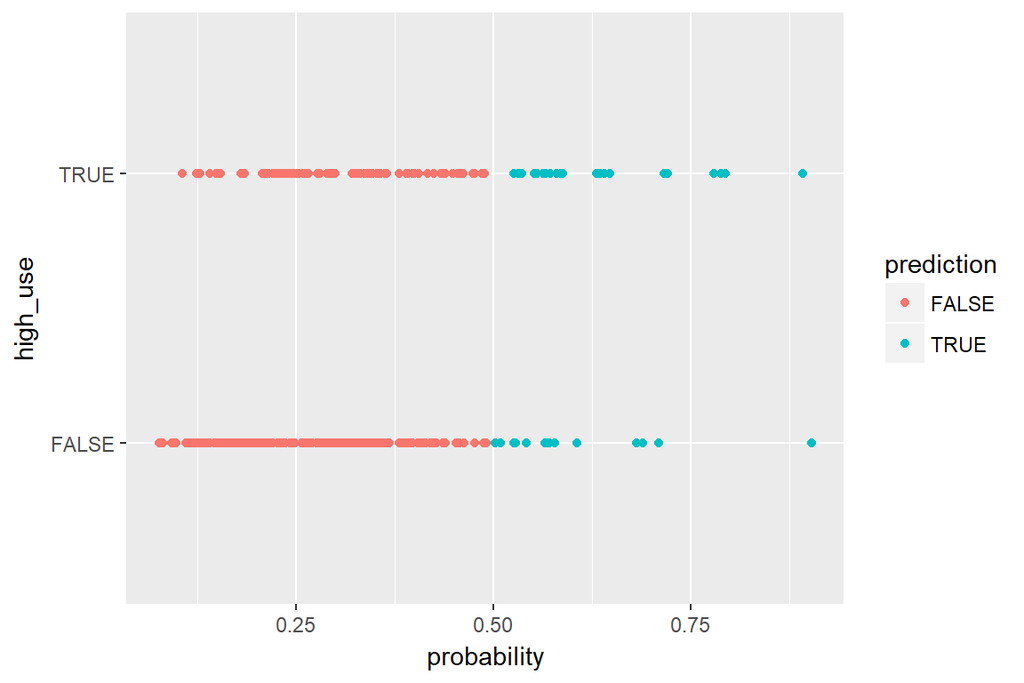

```r
g <- ggplot(alc, aes(x=probability, y=high_use, col=prediction))

g + geom_point()
```

Using this model we can predict that 6% of the cases will show a high consumption as a real value, 24% of the cases will appear as non high consumption while they really are, 4% will show as high alcohol cinsumption while they are not and 66% will appear as non high consumption as real values. this means that the variable used are not accurate enought to predict high consumption in students. This is confirmed with the next formula which tell us that 28% of our predictions are wrong.

```r
loss_func <- function(class, prob){
  n_wrong <- abs(class - prob) > 0.5
  mean(n_wrong)
}
loss_func(class=alc$high_use, prob=alc$probability)
```

```
## [1] 0.2827225
```

## Cross validation

```r
library(boot)
cv <- cv.glm(data=alc, cost=loss_func, glmfit = m, K=10)
cv$delta[1]
```

```
## [1] 0.2827225
```

## BONUS

Model with 7 variables

```r
m2 <- glm(high_use ~ sex + failures + absences + G3 + romantic + studytime + traveltime, data = alc, family = "binomial")
summary(m2)
```

```
##
## Call:
## glm(formula = high_use ~ sex + failures + absences + G3 + romantic +
##     studytime + traveltime, family = "binomial", data = alc)
##
## Deviance Residuals:
##     Min       1Q   Median       3Q      Max
## -2.2010  -0.8073  -0.5970   0.9465   2.1996
##
## Coefficients:
##             Estimate Std. Error z value Pr(>|z|)
## (Intercept) -1.14908    0.69465  -1.654 0.098091 .
## sexM         0.78466    0.25439   3.084 0.002040 **
## failures     0.24212    0.21052   1.150 0.250097
## absences     0.09012    0.02338   3.854 0.000116 ***
## G3          -0.03790    0.04013  -0.945 0.344868
## romanticyes -0.25050    0.26684  -0.939 0.347848
## studytime   -0.29826    0.16283  -1.832 0.066990 .
## traveltime   0.32439    0.16676   1.945 0.051748 .
## ---
## Signif. codes:  0 '***' 0.001 '**' 0.01 '*' 0.05 '.' 0.1 ' ' 1
##
## (Dispersion parameter for binomial family taken to be 1)
##
##     Null deviance: 465.68  on 381  degrees of freedom
## Residual deviance: 413.91  on 374  degrees of freedom
## AIC: 429.91
##
## Number of Fisher Scoring iterations: 4
```

```r
probabilities2 <- predict(m2, type = "response")
alc <- mutate(alc, probability2 = probabilities2)
alc <- mutate(alc, prediction2 = probability2 > 0.5)
loss_func(class=alc$high_use, prob=alc$probability2)
```

```
## [1] 0.2539267
```

```r
cv <- cv.glm(data=alc, cost=loss_func, glmfit = m2, K=10)
cv$delta[1]
```

```
## [1] 0.2696335
```

Model with 6 variables

```r
m3 <- glm(high_use ~ sex + failures + absences + G3 + studytime + traveltime, data = alc, family = "binomial")
summary(m3)
```

```
##
## Call:
## glm(formula = high_use ~ sex + failures + absences + G3 + studytime +
##     traveltime, family = "binomial", data = alc)
##
## Deviance Residuals:
##     Min       1Q   Median       3Q      Max
## -2.2403  -0.8124  -0.6067   0.9724   2.2271
##
## Coefficients:
##             Estimate Std. Error z value Pr(>|z|)
## (Intercept) -1.25183    0.68565  -1.826 0.067886 .
## sexM         0.79523    0.25386   3.132 0.001733 **
## failures     0.24437    0.21005   1.163 0.244673
## absences     0.08850    0.02336   3.789 0.000151 ***
## G3          -0.03367    0.03975  -0.847 0.396969
## studytime   -0.30870    0.16319  -1.892 0.058542 .
## traveltime   0.32403    0.16654   1.946 0.051694 .
## ---
## Signif. codes:  0 '***' 0.001 '**' 0.01 '*' 0.05 '.' 0.1 ' ' 1
##
## (Dispersion parameter for binomial family taken to be 1)
##
##     Null deviance: 465.68  on 381  degrees of freedom
## Residual deviance: 414.80  on 375  degrees of freedom
## AIC: 428.8
##
## Number of Fisher Scoring iterations: 4
```

```r
probabilities3 <- predict(m3, type = "response")
alc <- mutate(alc, probability3 = probabilities3)
alc <- mutate(alc, prediction3 = probability3 > 0.5)
loss_func(class=alc$high_use, prob=alc$probability3)
```

```
## [1] 0.2539267
```

```r
cv <- cv.glm(data=alc, cost=loss_func, glmfit = m3, K=10)
cv$delta[1]
```

```
## [1] 0.2722513
```

Model with 5 variables

```r
m4 <- glm(high_use ~ sex + failures + absences + G3 + traveltime, data = alc, family = "binomial")
summary(m4)
```

```
##
## Call:
## glm(formula = high_use ~ sex + failures + absences + G3 + traveltime,
##     family = "binomial", data = alc)
##
## Deviance Residuals:
##     Min       1Q   Median       3Q      Max
## -2.3015  -0.8015  -0.6238   0.9634   2.1717
##
## Coefficients:
##             Estimate Std. Error z value Pr(>|z|)
## (Intercept) -1.90678    0.59157  -3.223 0.001267 **
## sexM         0.92642    0.24399   3.797 0.000147 ***
## failures     0.31058    0.20649   1.504 0.132566
## absences     0.09356    0.02334   4.009  6.1e-05 ***
## G3          -0.04066    0.03909  -1.040 0.298259
## traveltime   0.33913    0.16650   2.037 0.041668 *
## ---
## Signif. codes:  0 '***' 0.001 '**' 0.01 '*' 0.05 '.' 0.1 ' ' 1
##
## (Dispersion parameter for binomial family taken to be 1)
##
##     Null deviance: 465.68  on 381  degrees of freedom
## Residual deviance: 418.52  on 376  degrees of freedom
## AIC: 430.52
##
## Number of Fisher Scoring iterations: 4
```

```r
probabilities4 <- predict(m4, type = "response")
alc <- mutate(alc, probability4 = probabilities4)
alc <- mutate(alc, prediction4 = probability4 > 0.5)
loss_func(class=alc$high_use, prob=alc$probability4)
```

```
## [1] 0.2486911
```

```r
cv <- cv.glm(data=alc, cost=loss_func, glmfit = m4, K=10)
cv$delta[1]
```

```
## [1] 0.2591623
```

Model with 4 variables

```r
m5 <- glm(high_use ~ sex + failures + absences + G3, data = alc, family = "binomial")
summary(m5)
```

```
##
## Call:
## glm(formula = high_use ~ sex + failures + absences + G3, family = "binomial",
##     data = alc)
##
## Deviance Residuals:
##     Min       1Q   Median       3Q      Max
## -2.1891  -0.8373  -0.6049   1.0357   2.1337
##
## Coefficients:
##             Estimate Std. Error z value Pr(>|z|)
## (Intercept) -1.29860    0.50329  -2.580  0.00987 **
## sexM         0.95321    0.24278   3.926 8.63e-05 ***
## failures     0.34596    0.20496   1.688  0.09142 .
## absences     0.09135    0.02293   3.983 6.81e-05 ***
## G3          -0.05115    0.03865  -1.323  0.18571
## ---
## Signif. codes:  0 '***' 0.001 '**' 0.01 '*' 0.05 '.' 0.1 ' ' 1
##
## (Dispersion parameter for binomial family taken to be 1)
##
##     Null deviance: 465.68  on 381  degrees of freedom
## Residual deviance: 422.65  on 377  degrees of freedom
## AIC: 432.65
##
## Number of Fisher Scoring iterations: 4
```

```r
probabilities5 <- predict(m5, type = "response")
alc <- mutate(alc, probability5 = probabilities5)
alc <- mutate(alc, prediction5 = probability5 > 0.5)
loss_func(class=alc$high_use, prob=alc$probability5)
```

```
## [1] 0.2643979
```

```r
cv <- cv.glm(data=alc, cost=loss_func, glmfit = m5, K=10)
cv$delta[1]
```

```
## [1] 0.2591623
```

Model with 3 variables

```r
m6 <- glm(high_use ~ sex + failures + G3, data = alc, family = "binomial")
summary(m6)
```

```
##
## Call:
## glm(formula = high_use ~ sex + failures + G3, family = "binomial",
##     data = alc)
##
## Deviance Residuals:
##     Min       1Q   Median       3Q      Max
## -1.5889  -0.8769  -0.6572   1.2696   1.9444
##
## Coefficients:
##             Estimate Std. Error z value Pr(>|z|)
## (Intercept) -0.69309    0.46719  -1.484 0.137935
## sexM         0.84756    0.23396   3.623 0.000292 ***
## failures     0.35970    0.20106   1.789 0.073616 .
## G3          -0.06080    0.03765  -1.615 0.106294
## ---
## Signif. codes:  0 '***' 0.001 '**' 0.01 '*' 0.05 '.' 0.1 ' ' 1
##
## (Dispersion parameter for binomial family taken to be 1)
##
##     Null deviance: 465.68  on 381  degrees of freedom
## Residual deviance: 441.32  on 378  degrees of freedom
## AIC: 449.32
##
## Number of Fisher Scoring iterations: 4
```

```r
probabilities6 <- predict(m6, type = "response")
alc <- mutate(alc, probability6 = probabilities6)
alc <- mutate(alc, prediction6 = probability6 > 0.5)
loss_func(class=alc$high_use, prob=alc$probability6)
```

```
## [1] 0.2879581
```

```r
cv <- cv.glm(data=alc, cost=loss_func, glmfit = m6, K=10)
cv$delta[1]
```

```
## [1] 0.2905759
```

Model with 2 variables

```r
m7 <- glm(high_use ~ sex + failures, data = alc, family = "binomial")
summary(m7)
```

```
##
## Call:
## glm(formula = high_use ~ sex + failures, family = "binomial",
##     data = alc)
##
## Deviance Residuals:
##     Min       1Q   Median       3Q      Max
## -1.5716  -0.9466  -0.6640   1.4273   1.8002
##
## Coefficients:
##             Estimate Std. Error z value Pr(>|z|)
## (Intercept)  -1.4000     0.1790  -7.821 5.24e-15 ***
## sexM          0.8294     0.2327   3.564 0.000365 ***
## failures      0.4873     0.1856   2.625 0.008662 **
## ---
## Signif. codes:  0 '***' 0.001 '**' 0.01 '*' 0.05 '.' 0.1 ' ' 1
##
## (Dispersion parameter for binomial family taken to be 1)
##
##     Null deviance: 465.68  on 381  degrees of freedom
## Residual deviance: 443.95  on 379  degrees of freedom
## AIC: 449.95
##
## Number of Fisher Scoring iterations: 4
```

```r
probabilities7 <- predict(m7, type = "response")
alc <- mutate(alc, probability7 = probabilities7)
alc <- mutate(alc, prediction7 = probability7 > 0.5)
loss_func(class=alc$high_use, prob=alc$probability7)
```

```
## [1] 0.2879581
```

```r
cv <- cv.glm(data=alc, cost=loss_func, glmfit = m7, K=10)
cv$delta[1]
```

```
## [1] 0.2931937
```